# Growth curve analysis using the Tecan 96-well plate reader - Knockout Strains May 29 2026

## Carrying capacity (k)

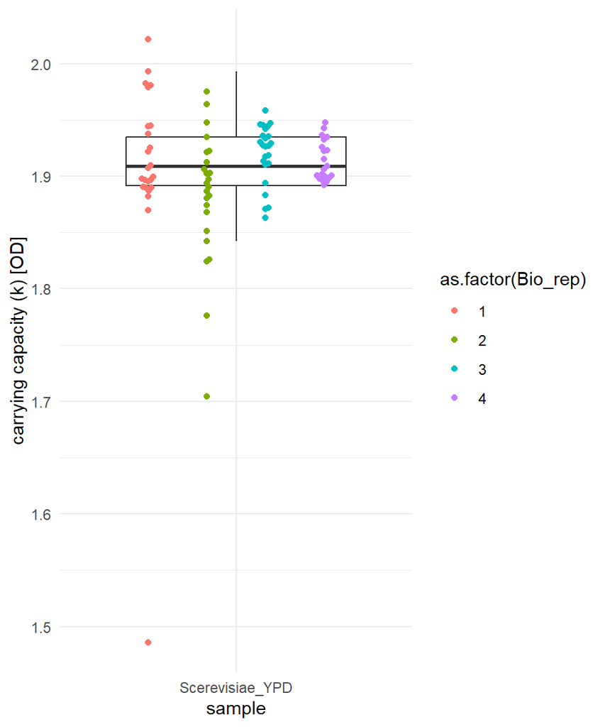

```r
ggplot(gc_out %>% filter(sample != "B"),
       aes(sample, k)) +
  geom_boxplot(outlier.shape = NA) +
  ggbeeswarm::geom_beeswarm(aes(color = as.factor(Bio_rep)),dodge.width = 0.8) +
  ylab("carrying capacity (k) [OD]")
```

## Initial population size (N0)

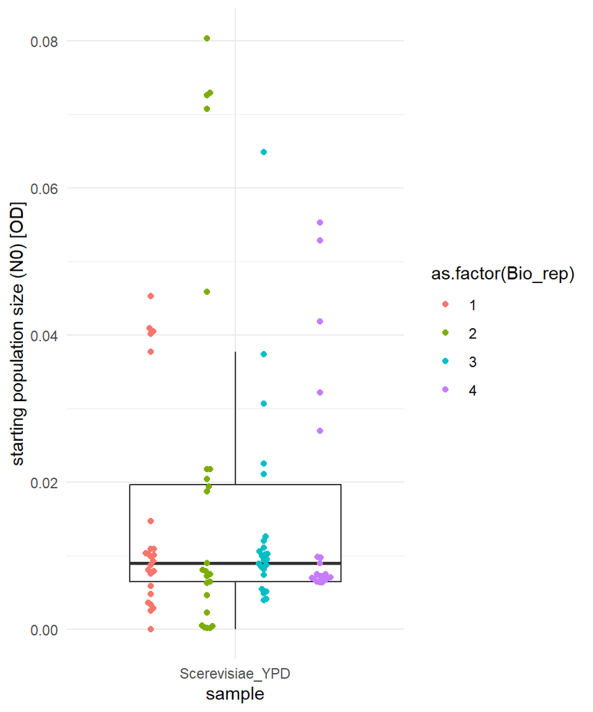

```r
ggplot(gc_out %>% filter(sample != "B"),
              aes(sample, n0)) +
  geom_boxplot(outlier.shape = NA) +
  ggbeeswarm::geom_beeswarm(aes(color = as.factor(Bio_rep)),dodge.width = 0.8) +
  ylab("starting population size (N0) [OD]")
```

## Genertion time (ln(2) / r)

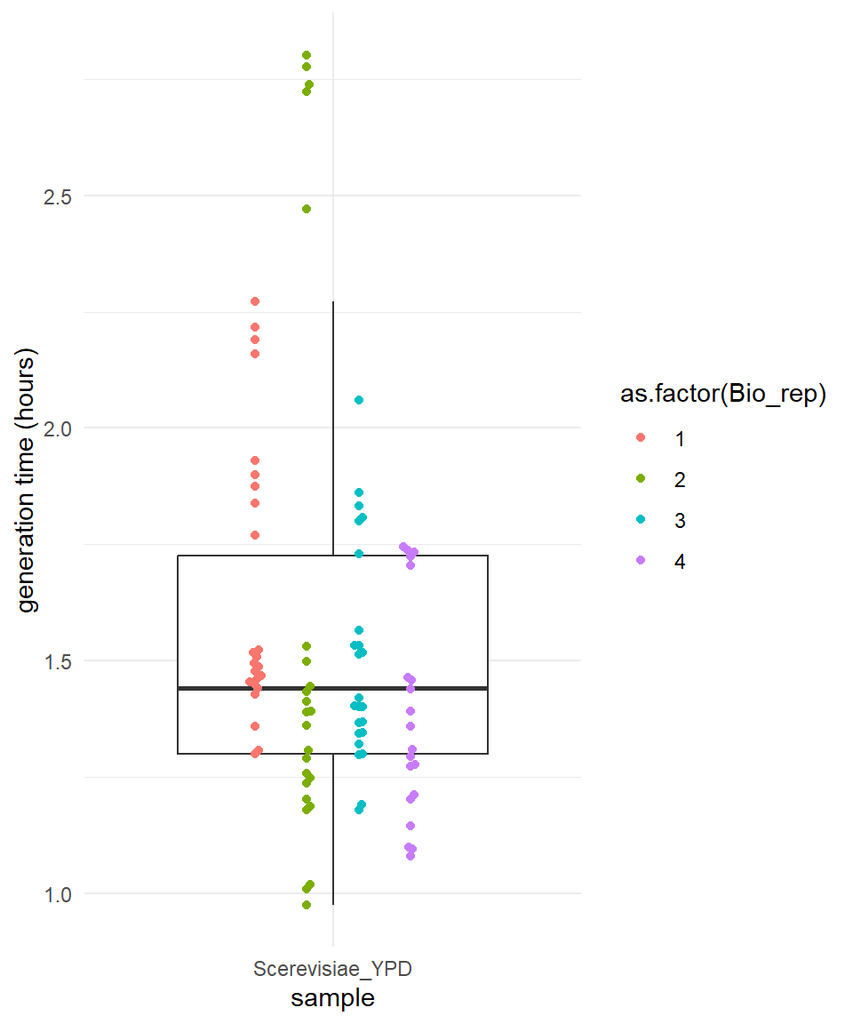

```r
ggplot(gc_out %>% filter(sample != "B"),
              aes(sample, t_gen)) +
  geom_boxplot(outlier.shape = NA) +
  ggbeeswarm::geom_beeswarm(aes(color = as.factor(Bio_rep)),dodge.width = 0.5) +
  ylab("generation time (hours)")
```

## Time to half maximal k (hours)

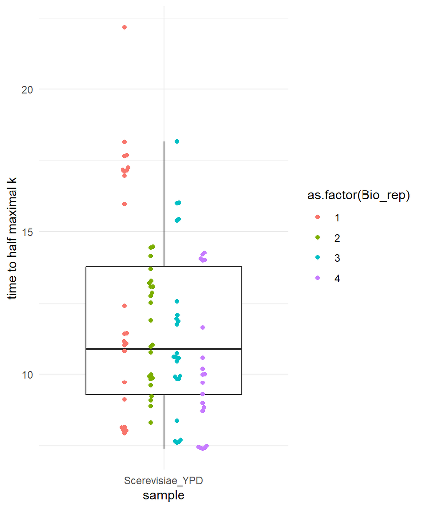

```r
ggplot(gc_out %>% filter(sample != "B"),
              aes(sample, t_mid)) +
  geom_boxplot(outlier.shape = NA) +
  ggbeeswarm::geom_beeswarm(aes(color = as.factor(Bio_rep)),dodge.width = 0.5) +
  ylab("time to half maximal k")
```

## Area under the logistic curve

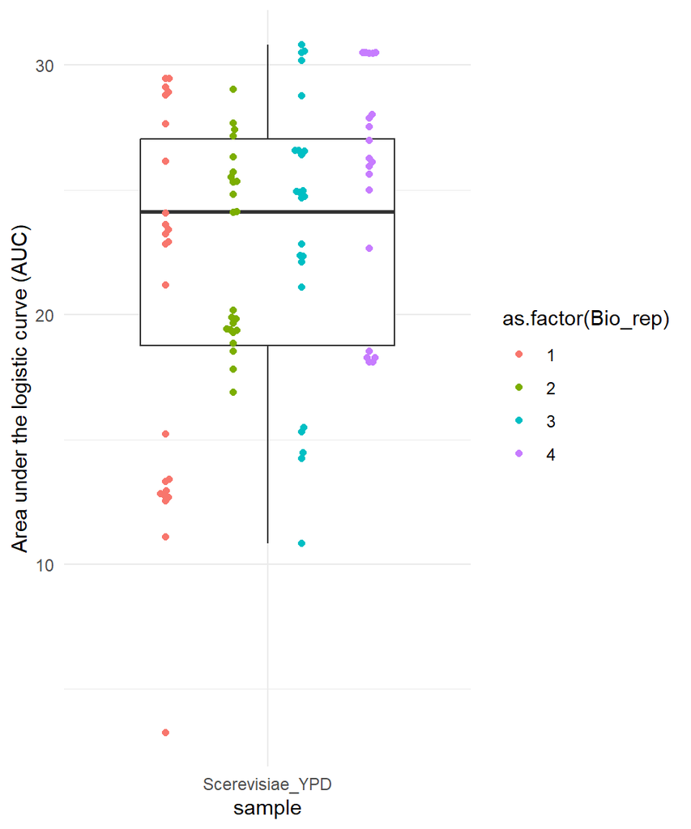

```r
ggplot(gc_out %>% filter(sample != "B"),
              aes(sample, auc_l)) +
  geom_boxplot(outlier.shape = NA) +
  ggbeeswarm::geom_beeswarm(aes(color = as.factor(Bio_rep)),dodge.width = 0.8) +
  ylab("Area under the logistic curve (AUC)")
```

## Area under the logistic curve - empirical

Determined by summing the areas of the trapezoids made up by connecting consecutive data points

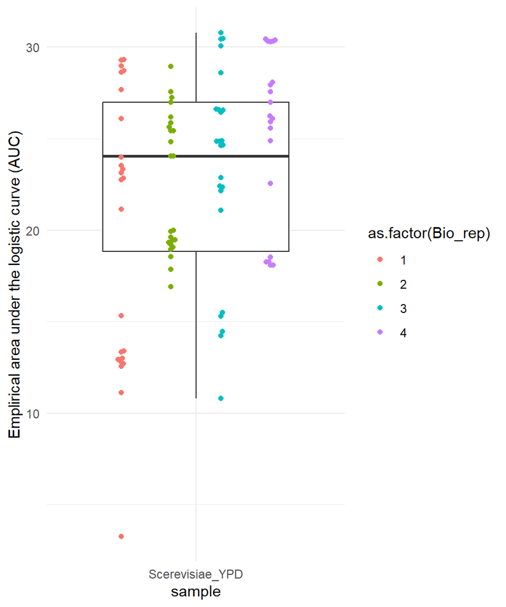

```r
ggplot(gc_out %>% filter(sample != "B"),
              aes(sample, auc_e)) +
  geom_boxplot(outlier.shape = NA) +
  ggbeeswarm::geom_beeswarm(aes(color = as.factor(Bio_rep)),dodge.width = 0.8) +
  ylab("Emplirical area under the logistic curve (AUC)")
```

# Summarize by sample

By summarizing over samples we can compute the average of each parameter and the variance in the measurements.

```r
summary = gc_out %>%
  filter(sample != "B") %>%
  group_by(sample) %>%
  summarise(mean_r = mean(r), var_r = var(r), mean_k = mean(k), var_k = var(k),
            mean_generation_time = mean(t_gen), variance_generation_time =  var(t_gen))
summary %>%
  knitr::kable()
```

| sample | mean_r | var_r | mean_k | var_k | mean_generation_time | variance_generation_time |
| --- | --- | --- | --- | --- | --- | --- |
| Scerevisiae_YPD | 0.4741435 | 0.0096353 | 1.905136 | 0.0037744 | 1.538019 | 0.1523323 |

# Plot logistic fits over data

In order to visually inspect the quality of the model fits we plot the data and the fits.

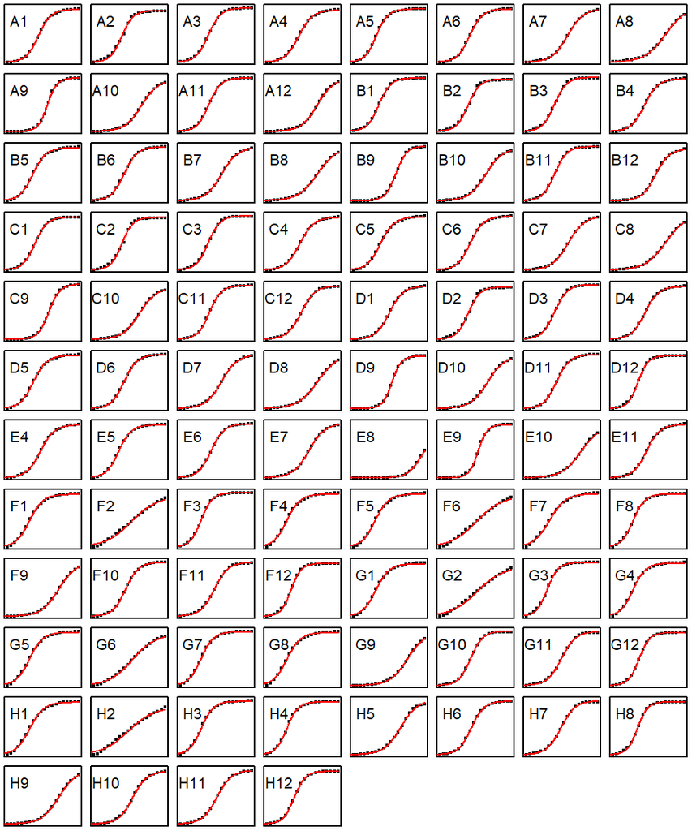

```r
#the following code is copied from the growthcurver vignette

d <- data_od %>% select(gc_out$well[which(gc_out$sample != "B")], time)

# Let's create an output data frame to store the results in.
# We'll create it so that it is the right size (it's faster this way!),
# but leave it empty.
num_analyses <- length(names(d)) - 1
d_gc <- data.frame(sample = character(num_analyses),
                   k = numeric(num_analyses),
                   n0  = numeric(num_analyses),
                   r = numeric(num_analyses),
                   t_mid = numeric(num_analyses),
                   t_gen = numeric(num_analyses),
                   auc_l = numeric(num_analyses),
                   auc_e = numeric(num_analyses),
                   sigma = numeric(num_analyses),
                   stringsAsFactors = FALSE)



# Now, loop through all of the columns in the data frame. For each column,
# run Growthcurver, save the most useful metrics in the output data frame,
# and make a plot of all the growth curve data and their best fits.

# First, create a plot for each of the wells in the 96-well plate.

# Uncomment the next line to save the plots from your 96-well plate to a
# pdf file in the working directory.
#pdf("growthcurver.pdf", height = 8.5, width = 11)
par(mfrow = c(12,8))
par(mar = c(0.25,0.25,0.25,0.25))
y_lim_max <- max(d[,setdiff(names(d), "time")]) - min(d[,setdiff(names(d), "time")])

n <- 1    # keeps track of the current row in the output data frame
for (col_name in names(d)) {

  # Don't process the column called "time".
  # It contains time and not absorbance data.
  if (col_name != "time")  {

    # Create a temporary data frame that contains just the time and current col
    d_loop <- d[, c("time", col_name)]

# Do the background correction.

    # Background correction option 1: subtract the minimum value in a column
    #                                 from all measurements in that column
    min_value <- min(d_loop[, col_name])
    d_loop[, col_name] <- d_loop[, col_name] - min_value

    # Background correction option 2: subtract the mean value of blank wells
    #                                 over the course the experiment
    #                                 (Replace B2, D8, G11 with the column
    #                                  names of your media-only wells)
    #d$blank <- apply(d[, c("B2", "D8", "G11")], 1, mean)
    #d$A1 <- d$A1 - d$blank

    # Now, call Growthcurver to calculate the metrics using SummarizeGrowth
    gc_fit <- SummarizeGrowth(data_t = d_loop[, "time"],
                              data_n = d_loop[, col_name],
                              bg_correct = "none")

    # Now, add the metrics from this column to the next row (n) in the
    # output data frame, and increment the row counter (n)
    d_gc$sample[n] <- col_name
    d_gc[n, 2:9] <- c(gc_fit$vals$k,
                      gc_fit$vals$n0,
                      gc_fit$vals$r,
                      gc_fit$vals$t_mid,
                      gc_fit$vals$t_gen,
                      gc_fit$vals$auc_l,
                      gc_fit$vals$auc_e,
                      gc_fit$vals$sigma)
    n <- n + 1

    # Finally, plot the raw data and the fitted curve
    # Here, I'll just print some of the data points to keep the file size smaller
    n_obs <- length(gc_fit$data$t)
    idx_to_plot <- 1:20 / 20 * n_obs
    plot(gc_fit$data$t[idx_to_plot], gc_fit$data$N[idx_to_plot],
         pch = 20,
         #xlim = c(0, trim_at_time),
         ylim = c(0, y_lim_max),
         cex = 0.6, xaxt = "n", yaxt = "n")
     text(x = 5, y = y_lim_max, labels = col_name, pos = 1)
     lines(gc_fit$data$t, predict(gc_fit$model), col = "red")
  }
}
```

# Output data

Write a csv files containing the results of the logistic fits for further analysis.

```r
write_csv(gc_out, paste0(filepath,out))
```